# CFRM 502, Winter 2020

# Instructor: Bahman Angoshtari

# Lecture 7

**Chapter 12:** time series analysis, white noise, AR(1) model and its properties

$\newcommand\Fc{\mathscr{F}}$ $\newcommand{\eps}{\varepsilon}$ $\newcommand{\Var}{\operatorname{Var}}$ $\newcommand\Cov{\operatorname{Cov}}$ $\newcommand{\sig}{\sigma}$ $\newcommand{\al}{\alpha}$ $\newcommand{\gam}{\gamma}$ $\newcommand\ph{\varphi}$ $\newcommand\rb{\bar{r}}$ $\newcommand{\Xb}{\bar{X}}$ $\newcommand{\Yb}{\bar{Y}}$ $\newcommand\Eb{\mathbb{E}}$ $\newcommand\Pb{\mathbb{P}}$ $\newcommand\Qb{\mathbb{Q}}$ $\newcommand\Rb{\mathbb{R}}$ $\newcommand\Zb{\mathbb{Z}}$ $\newcommand\Nb{\mathbb{N}}$ $\newcommand\Av{\textbf{A}}$ $\newcommand\Fv{\textbf{F}}$ $\newcommand\Gv{\textbf{G}}$ $\newcommand\Hv{\textbf{H}}$ $\newcommand\Kv{\textbf{K}}$ $\newcommand\Iv{\textbf{I}}$ $\newcommand\Pv{\textbf{P}}$ $\newcommand\Sv{\textbf{S}}$ $\newcommand\Xv{\textbf{X}}$ $\newcommand\Yv{\textbf{Y}}$ $\newcommand\Zv{\textbf{Z}}$ $\newcommand\av{\mathbf{a}}$ $\newcommand\xv{\mathbf{x}}$ $\newcommand\yv{\mathbf{y}}$ $\newcommand\zv{\mathbf{z}}$ $\newcommand\Cv{\mathbf{C}}$ $\newcommand\mv{\mathbf{m}}$ $\newcommand\nv{\mathbf{n}}$ $\newcommand\pv{\mathbf{p}}$ $\newcommand\sv{\mathbf{s}}$ $\newcommand\wv{\mathbf{w}}$ $\newcommand\Wv{\textbf{W}}$ $\newcommand\betav{{\boldsymbol\beta}}$ $\newcommand\etav{{\boldsymbol\eta}}$ $\newcommand\epsv{{\boldsymbol\varepsilon}}$ $\newcommand\delv{{\boldsymbol\delta}}$ $\newcommand\Lamv{{\boldsymbol\Lambda}}$ $\newcommand\lamv{{\boldsymbol\lambda}}$ $\newcommand\muv{{\boldsymbol\mu}}$ $\newcommand\piv{{\boldsymbol\pi}}$ $\newcommand\Pbh{\widehat{\Pb}}$ $\newcommand\phh{\widehat{\varphi}}$ $\newcommand\Ebh{\widehat{\Eb}}$ $\newcommand\Qh{\widehat{Q}}$ $\newcommand\Ih{\widehat{I}}$ $\newcommand\pih{\widehat{\pi}}$ $\newcommand\Pih{\widehat{\Pi}}$ $\newcommand\Wh{\widehat{W}}$ $\newcommand\Fh{\widehat{F}}$ $\newcommand\Yh{\widehat{Y}}$ $\newcommand\Yvh{\widehat{\Yv}}$ $\newcommand\Ah{\widehat{\Ac}}$ $\newcommand\uh{\widehat{u}}$ $\newcommand\vh{\widehat{v}}$ $\newcommand\fh{\widehat{f}}$ $\newcommand\hh{\widehat{h}}$ $\newcommand\Bh{\widehat{B}}$ $\newcommand\rhoh{\widehat{\rho}}$ $\newcommand\nuh{\widehat{\nu}}$ $\newcommand\varphih{\widehat{\varphi}}$ $\newcommand\alh{\widehat{\al}}$ $\newcommand\thetah{\widehat{\theta}}$ $\newcommand\betah{\widehat{\beta}}$ $\newcommand\betavh{\widehat{\boldsymbol\beta}}$ $\newcommand\kaph{\widehat{\kappa}}$ $\newcommand\sigh{\widehat{\sigma}}$ $\newcommand\epsh{\widehat{\eps}}$ $\newcommand\epsvh{\widehat{\epsv}}$ $\newcommand\epst{\widetilde{\eps}}$ $\newcommand\muh{\widehat{\mu}}$ $\newcommand\dd{\mathrm{d}}$ $\newcommand\ee{\mathrm{e}}$

# 0. Overview of the lecture

- In today's lecture, we study our first timeseries model, namely the AR(1) process
- Since the AR(1) model is simple, we study its properties in full detail. For later timeseries models, we present less detail.

# 1. Time series analysis

- Consider a stochastic process $\{r_0, r_1,\dots\}$
- The goal of time series analysis is to answer the following questions:
  - What is the information contained in $\{r_t\}$?
  - What is a parsimonious mathematical model for $\{r_t\}$?
- At time t, just before observing $r_t$:
  - Available data $\Fc_{t-1} = \{r_0, \dots, r_{t-1}\}$
  - $r_t$ is decomposed into two parts

\begin{align*} r_t = \underbrace{\Eb(r_t|\Fc_{t-1})}_{\text{prediction based on }\Fc_{t-1}} + \underbrace{\sqrt{\Var(r_t|\Fc_{t-1})} \, \eps_t}_{\text{unpredictable based on }\Fc_{t-1}} \end{align*}

- Here, $\mu_t := \Eb(r_t|\Fc_{t-1})$ is called the **"conditional mean"**
- $\sig_t:= \sqrt{\Var(r_t|\Fc_{t-1})}$ is called the **"conditional standard deviation"** or **"volatility"**
- $\{\eps_t\}$ is a **"white noise"** or a **"weak white noise"**

**Definition:** A white noise with variance $\sig^2$, denoted by WN$(0,\sig^2)$, is a sequence of independent and identically distributed random variables with mean 0 and variance $\sig^2$

**Definition:** A weak white noise with variance $\sig^2$, denoted by weak WN$(0,\sig^2)$, is a weakly stationary process with mean 0, variance $\sig^2$, and autocorrelation function $\rho(h)=0$ for all $h>0$

- Weak white noise is the simplest form of weakly stationary processes, with ACF $\rho(h) = 0$ for $h\ge1$
- How can we test that a weakly stationary process is weak WN?
- First, establish that the process is stationary (by using unit-root test that we will learn later). Then, use ACF plot and Ljung-Box test to see of autocorrelations are zero at all lags

\begin{align*} r_t = \underbrace{\mu_t}_{\text{prediction based on }\Fc_{t-1}} + \underbrace{\sig_t \, \eps_t}_{\text{unpredictable based on }\Fc_{t-1}} \end{align*}

- Note that $\mu_t$ and $\sigma_t$ are both functions of $r_0, \dots, r_{t-1}$, that is

\begin{align*} \mu_t &:= \mu(t,r_0,r_1,\dots,r_{t-1})\\ \sig_t &:= \sig(t, r_0, r_1, \dots, r_{t-1}) \end{align*}

- A time series model is an specification of $\mu_t$ and $\sigma_t$
- A model of $\mu_t$ is called **"the mean equation"**
- A model of $\sig_t$ is called **"the volatility equation"**
- In Chapters 12 and 13 (the next 4 lectures), we focus on the mean modeling (ARIMA models and their variations)
- In Chapter 14, we consider volatility modeling (GARCH models).

# 2. The AR(1) model and its properties

- In an **"autoregressive model of order 1,"** denoted by AR(1), the mean and volatility equations are

\begin{align*} \mu_t &= \varphi_0 + \varphi_1 r_{t-1}\\ \sig_t &= \sig^2_\eps. \end{align*}

- More specifically, the AR(1) model has the following form

  $ r_t = \varphi_0 + \varphi_1 r_{t-1} + \eps_t, t\in\{1,2,\dots\}$

  where, $\{\eps_t\}$ is a weak WN$(0,\sig^2_\eps)$
- There are only 3 (unknown) parameters, namely $\varphi_0, \varphi_1,$ and $ \sig^2_\eps$
- Let us define the **lag operator** $B r_{t} = r_{t-1}$.
- We then write the AR(1) model as follows:

\begin{align*} \begin{cases} (1-\varphi_1 B) r_t = \varphi_0 + \eps_t;\quad\quad t=1,2,\dots\\ \eps_t\sim \text{ weak WN}(0,\sig_\eps^2) \end{cases} \end{align*}

## 2.1. Mean, variance, and ACF of AR(1) process

- Note that the specification above is a recursive equation. Let us see if we can solve for $r_t$ in terms of the parameters and the weak WN
- We have:

\begin{align*} r_1 &= \varphi_0 + \ph_1 r_0 + \eps_1\\ r_2 &= \varphi_0 + \ph_1 r_1 + \eps_2 = \ph_0(1+\ph_1) + \ph_1^2 r_0 + \eps_2 +\ph_1\,\eps_1 \end{align*}

\begin{align*} r_3 &= \dots = \ph_0(1+\ph_1 + \ph_1^2) + \ph_1^3 r_0 +\eps_3 + \ph_1\,\eps_2 + \ph_1^2\eps_1\\ \vdots \end{align*}

- In general, we have

\begin{align*} r_t &= \dots = \ph_0(1+\ph_1+\dots + \ph_1^{t-1}) + \ph_1^t r_0 + \eps_t + \ph_1\,\eps_{t-1} + \dots + \ph_1^{t-1}\eps_1\\ &= \frac{\ph_0}{1-\ph_1}(1-\ph_1^t) + \ph_1^t r_0 + \sum_{h=0}^{t-1} \ph_1^h \eps_{t-h} \tag{$\star$} \end{align*}

- Here, we used the formula for geometric series $\displaystyle \sum_{h=0}^{n-1} a^h = 1+a+\dots+a^{n-1}= \frac{1-a^n}{1-a}$
- We can also find a slightly more general relationship. For $k\in\{1,\dots, t\}$,

\begin{align*} r_t &= \ph_0(1+\ph_1+\dots + \ph_1^{k-1}) + \ph_1^k r_{t-k} \\ &\qquad \qquad+ \eps_t + \ph_1\,\eps_{t-1} + \dots + \ph_1^{k-1}\eps_{t-(k-1)}\\ &= \frac{\ph_0}{1-\ph_1}(1-\ph_1^k) + \ph_1^k r_{t-k} + \sum_{h=0}^{k-1} \ph_1^h \eps_{t-h} \tag{$\star\star$} \end{align*}

- Let us find the first two moments of an AR(1) process
- Using equation $(\star)$, we may find the expectation of $r_t$

\begin{align*} \Eb(r_t) &\overset{(\star)}{=}\Eb\left(\frac{\ph_0}{1-\ph_1}(1-\ph_1^t) + \ph_1^t r_0 + \sum_{h=0}^{t-1} \ph_1^h \eps_{t-h}\right)\\ &= \frac{\ph_0}{1-\ph_1}(1-\ph_1^t) + \ph_1^t \Eb(r_0) + \sum_{h=0}^{t-1} \ph_1^h \Eb(\eps_{t-h})\\ &= \frac{\ph_0}{1-\ph_1}(1-\ph_1^t) + \ph_1^t \Eb(r_0) = \frac{\ph_0}{1-\ph_1} + \ph_1^t\left( \Eb(r_0) - \frac{\ph_0}{1-\ph_1}\right) \end{align*}

- Similarly, the variance of $r_t$ is given by

\begin{align*} \Var(r_t) &\overset{(\star)}{=}\Var\left(\frac{\ph_0}{1-\ph_1}(1-\ph_1^t) + \ph_1^t r_0 + \sum_{h=0}^{t-1} \ph_1^h \eps_{t-h}\right)\\ &= \ph_1^{2t} \Var(r_0) + \sum_{h=0}^{t-1} \ph_1^{2h} \Var(\eps_{t-h})\\ &= \ph_1^{2t} \Var(r_0) + \frac{\sig^2_\eps}{1-\ph_1^2}(1-\ph_1^{2t})\\ &= \ph_1^{2t} \left(\Var(r_0) - \frac{\sig^2_\eps}{1-\ph_1^2}\right) + \frac{\sig^2_\eps}{1-\ph_1^2} \end{align*}

- To get the autocovariance function, we use $(\star\star)$

\begin{align*} \Cov(r_t, r_{t-k}) &\overset{(\star\star)}{=}\Cov\left(\frac{\ph_0}{1-\ph_1}(1-\ph_1^k) + \ph_1^k r_{t-k} + \sum_{h=0}^{k-1} \ph_1^h \eps_{t-h},\, r_{t-k}\right)\\ &=\Cov\left(\ph_1^k r_{t-k}, r_{t-k}\right) + \sum_{h=0}^{k-1} \ph_1^h\Cov\left(\eps_{t-h}, r_{t-k}\right) = \ph_1^k \Var(r_{t-k}) \end{align*}

- Note that $\sum_{h=0}^{k-1} \ph_1^h\Cov\left(\eps_{t-h}, r_{t-k}\right)=0$ since $r_{t-k}$ is uncorrelated with any of the random variables $\eps_{t-k+1}, \dots, \eps_{t}$
- We have thus proved the following equations. For all $t\in\{1,2,\dots\}$

\begin{align*} \Eb(r_t) &= \frac{\ph_0}{1-\ph_1} + \ph_1^t\left( \Eb(r_0) - \frac{\ph_0}{1-\ph_1}\right)\\ \Var(r_t) &= \ph_1^{2t} \left(\Var(r_0) - \frac{\sig^2_\eps}{1-\ph_1^2}\right) + \frac{\sig^2_\eps}{1-\ph_1^2}\\ \Cov(r_t, r_{t-k}) &= \ph_1^k \Var(r_{t-k}) \end{align*}

## 2.2. Stationary AR(1) processes

- Looking at the formulas for the mean and variance of the AR(1) model, it is clear that

\begin{align*} \Eb(r_0) = \frac{\ph_0}{1-\ph_1} \quad\Longleftrightarrow\quad\quad \Eb(r_t) = \frac{\ph_0}{1-\ph_1} \end{align*}

\begin{align*} \Var(r_0) = \frac{\sig^2_\eps}{1-\ph_1^2} \quad\Longleftrightarrow \quad\quad \Var(r_t) = \frac{\sig^2_\eps}{1-\ph_1^2} \end{align*}

- Thus, $\Eb(r_t)$ and $\Var(r_t)$ are time invariant if and only if $\Eb(r_0) = \frac{\ph_0}{1-\ph_1}$ and $\Var(r_0) = \frac{\sig^2_\eps}{1-\ph_1^2}$
- The latter condition requires $|\ph_1|<1$, since the variance can only be positive.
- If these conditions hold, then $\Cov(r_t, r_{t-k}) = \ph_1^k\frac{\sig^2_\eps}{1-\ph_1^2}$, which is not a function of $t$.
- We then get the following result:

**Theorem:** An AR(1) process is stationary if

\begin{align*} |\ph_1|<1 \end{align*}

\begin{align*} \Eb(r_0) = \frac{\ph_0}{1-\ph_1} \end{align*}

and

\begin{align*} \Var(r_0) = \frac{\sig^2_\eps}{1-\ph_1^2} \end{align*}

For a stationary AR(1) process, we have $\Eb(r_t) = \frac{\ph_0}{1-\ph_1}$, $\Var(r_t) = \frac{\sig^2_\eps}{1-\ph_1^2}$, $\gam(k) = \ph_1^k\frac{\sig^2_\eps}{1-\ph_1^2}$, and $\rho(k) = \ph_1^k$

## 2.3. Alternative representations of AR(1) processes

- There are two alternative forms for AR(1) process
- Let $\mu = \frac{\ph_0}{1-\ph_1}$ or, equivalently, $\ph_0=\mu(1-\ph_1)$.
- Then, $r_t = \varphi_0 + \ph_1 r_{t-1} + \eps_t$ can be re-written as

\begin{align*} r_t - \mu = \ph_1(r_{t-1}-\mu) + \eps_t \end{align*}

- This equation is called the **"mean-adjusted"** form of the AR(1) process and is used by R
- Using the lag operator $B\,r_t=r_{t-1}$, the mean adjusted form can be written as follows:

\begin{align*} \begin{cases} (1-\varphi_1 B) (r_t - \mu) = \eps_t;\quad\quad t=1,2,\dots\\ \eps_t\sim \text{ weak WN}(0,\sig_\eps^2) \end{cases} \end{align*}

- To get the second form, we expand the time-index to $-\infty$ by assuming $\{\dots, \eps_{-2}, \eps_{-1}, \eps_0, \eps_{1}, \eps_{2}, \dots\}$ are weak WN$(0,\sig^2_\eps)$ and consider the AR(1) process

\begin{align*} r_t = \ph_0 + \ph_1\,r_{t-1} + \eps_t;\quad\quad t\in\{\dots,-2,-1,0,1,2,\dots\} \end{align*}

- Then, equation $(\star\star)$ holds for any $k\in\{1,2,\dots\}$

\begin{align*} r_t = \frac{\ph_0}{1-\ph_1}(1-\ph_1^k) + \ph_1^k r_{t-k} + \sum_{h=0}^{k-1} \ph_1^h \eps_{t-h} \end{align*}

- Assuming that $|\ph_1|<1$ and letting $k\to\infty$ yields

\begin{align*} r_t = \mu + \sum_{h=0}^{\infty} \ph_1^h \eps_{t-h} \end{align*}

- Here, $\mu = \frac{\ph_0}{1-\ph_1}$ as before
- This is called the **"MA($\infty$)"** form of an AR(1) process. The reason for this naming will be clear once we study **"moving average"** processes

## 2.4. Non-stationary AR(1) processes

- If $\ph_1 = 1$, then the AR(1) process becomes the "random walk process"

  $r_t = \ph_0 + r_{t-1} + \eps_t$
- We then obtain

\begin{align*} r_t &= \ph_0\,t + r_0 + \eps_t + \eps_{t-1} + \dots + \eps_1 \end{align*}

- Thus, $\Eb(r_t) =$ $ \ph_0\,t +$ $ \Eb(r_0)$ and $\Var(r_t) $ $=$ $ \Var(r_0)$ $ + $ $\sig_\eps^2\,t$
- Note that, we can no longer find values for $\Eb(r_0)$ and $\Var(r_0)$ for which the first two moments become time-invariant
- The case $\ph=-1$ and $|\ph|>1$ lead to similar conclusion (check these cases)

## 2.5. Numerical examples of AR(1) processes

- Let us see how the (theoretical) ACF function of AR(1) processes look like

```r
# Setting parameters of the Jupyter notebook
sc = .75
options(repr.plot.width=16*sc,
        repr.plot.height=7*sc,
        repr.plot.pointsize = 13, # Text height in pt
        repr.plot.bg        = 'white',
        repr.plot.antialias = 'gray',
        #nice medium-res DPI
        repr.plot.res       = 300,
        #jpeg quality bumped from default
        repr.plot.quality   = 90,
        #vector font family
        repr.plot.family    = 'serif') # Vector font family. 'sans', 'serif', 'mono' or a specific one
```

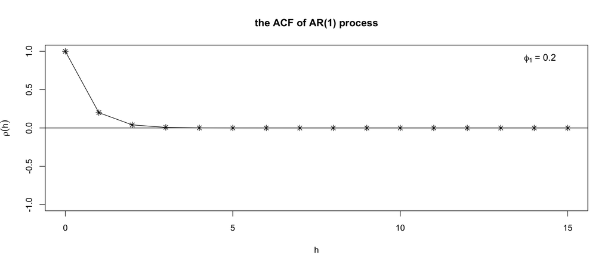

```r
phi = 0.2
y = phi^(0:15)
plot(0:15, y, xlab="h", ylab=expression(rho(h)), ylim=c(-1,1), type = 'l',
    main="the ACF of AR(1) process")
points(0:15, y, pch = 8)
text(par("usr")[2], par("usr")[4], bquote(phi[1]~.(paste("=",as.character(phi)))),
     adj=c(2,2), cex = 1.1)
abline(h=0)
```

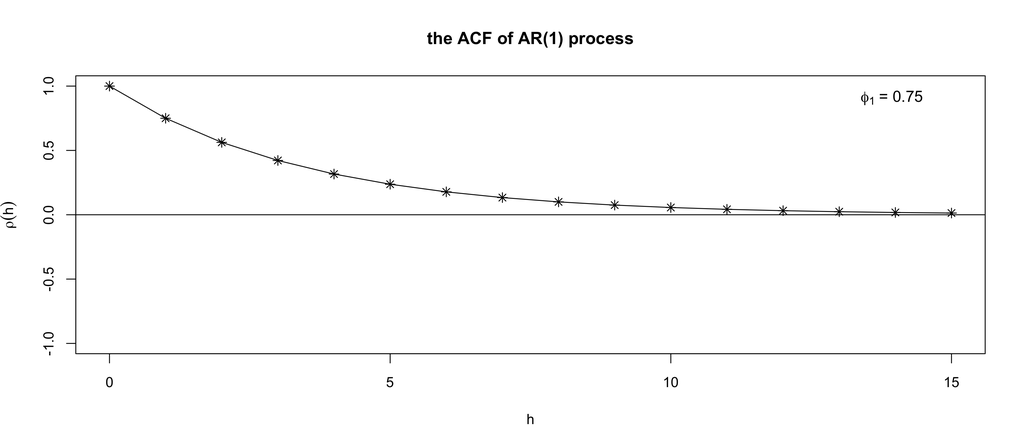

```r
phi = 0.75
y = phi^(0:15)
plot(0:15, y, xlab="h", ylab=expression(rho(h)), ylim=c(-1,1), type = 'l',
    main="the ACF of AR(1) process")
points(0:15, y, pch = 8)
text(par("usr")[2], par("usr")[4], bquote(phi[1]~.(paste("=",as.character(phi)))),
     adj=c(2,2), cex = 1.1)
abline(h=0)
```

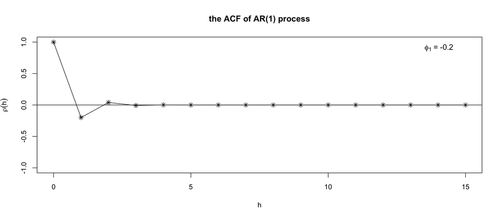

```r
phi = -0.2
y = phi^(0:15)
plot(0:15, y, xlab="h", ylab=expression(rho(h)), ylim=c(-1,1), type = 'l',
    main="the ACF of AR(1) process")
points(0:15, y, pch = 8)
text(par("usr")[2], par("usr")[4], bquote(phi[1]~.(paste("=",as.character(phi)))),
     adj=c(2,2), cex = 1.1)
abline(h=0)
```

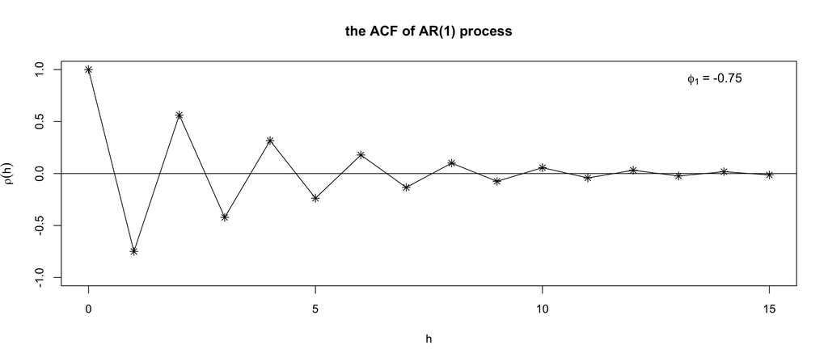

```r
phi = -0.75
y = phi^(0:15)
plot(0:15, y, xlab="h", ylab=expression(rho(h)), ylim=c(-1,1), type = 'l',
    main="the ACF of AR(1) process")
points(0:15, y, pch = 8)
text(par("usr")[2], par("usr")[4], bquote(phi[1]~.(paste("=",as.character(phi)))),
     adj=c(2,2), cex = 1.1)
abline(h=0)
```

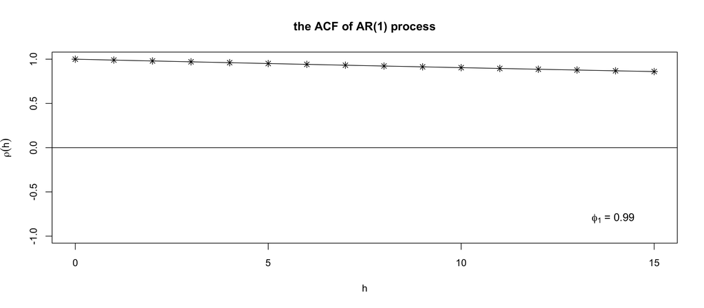

```r
phi = 0.99
y = phi^(0:15)
plot(0:15, y, xlab="h", ylab=expression(rho(h)), ylim=c(-1,1), type = 'l',
    main="the ACF of AR(1) process")
points(0:15, y, pch = 8)
text(par("usr")[2], par("usr")[3], bquote(phi[1]~.(paste("=",as.character(phi)))),
     adj=c(2,-2), cex = 1.1)
abline(h=0)
```

- Next, let us simulate some AR(1) processes

```r
set.seed(8716)
e = rnorm(500)
phi = c(-0.75, 0.995, 1.00, 1.005)
r = list(e,e,e,e)
for (i in 1:length(r)){
  for (t in 2:length(e)){
    r[[i]][t] = phi[i]*r[[i]][t-1]+e[t]
  }
}
```

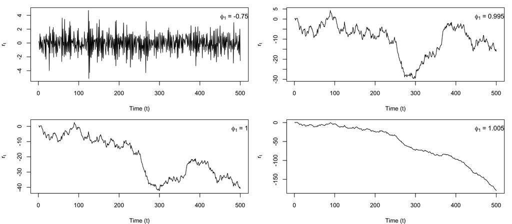

```r
par(mar=c(4,4,1,1));par(mfrow=c(2,2))
for (i in 1:length(r)){
  plot(r[[i]],type="l",xlab="Time (t)",ylab=expression(r[t]))
  text(par("usr")[2], par("usr")[4],
       bquote(phi[1]~.(paste("=",phi[i]))), adj = c( 1, 2 ), cex = 1.1)
}
```

- Let us find the ACF plots of the simulated processes

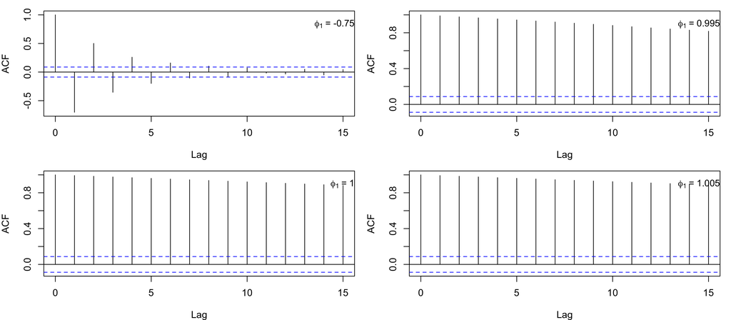

```r
par(mar=c(4,4,1,1));par(mfrow=c(2,2),cex.axis=1.15,cex.lab=1.15,cex.main=1.15)
for (i in 1:length(r)) {
    acf(r[[i]], lag.max = 15)
    text(par("usr")[2], par("usr")[4],
         bquote(phi[1]~.(paste("=",phi[i]))), adj = c( 1, 2 ), cex = 1.1)
}
```

- Do the two bottom plots (for $\phi_1=1$ and $\phi_1=1.005$) make sense?
- They don't make any sense, since the corresponding AR(1) processes are not stationary. A non-stationary process does not have an autocorrelation function!
- Let us compare the sample and theoretical ACF for the stationary AR(1) processes

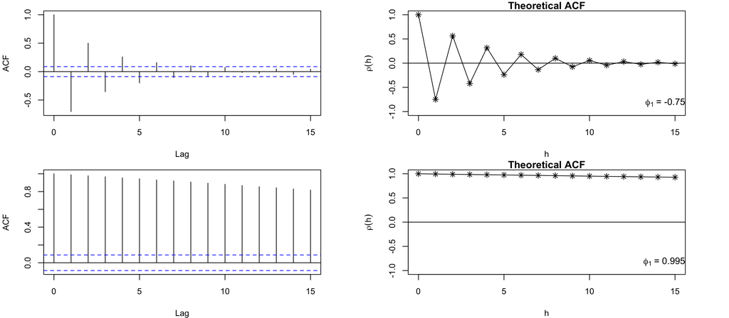

```r
par(mar=c(4,4,1,4));par(mfrow=c(2,2))
for(i in 1:2){
  acf(r[[i]], lag.max = 15,)
  y = phi[i]^(0:15)
  plot(0:15, y, main="Theoretical ACF",
       xlab="h", ylab=expression(rho(h)), ylim=c(-1,1), type = 'l')
  points(0:15, y, pch = 8);  abline(h=0)
  text(par("usr")[2], par("usr")[3],
       bquote(phi[1]~.(paste("=",phi[i]))), adj = c( 1, -1 ), cex = 1.1)
}
```